# Data Visualization in R (Part 1)

Bhaskarjit Sarmah

2 August 2017

In this report I will use different datasets to plot the data to gain some meaningful instights using `ggplot2` package

```r
library(ggplot2)
```

## Some basic plots

First load the `mtcars` dataset

```r
data("mtcars")
```

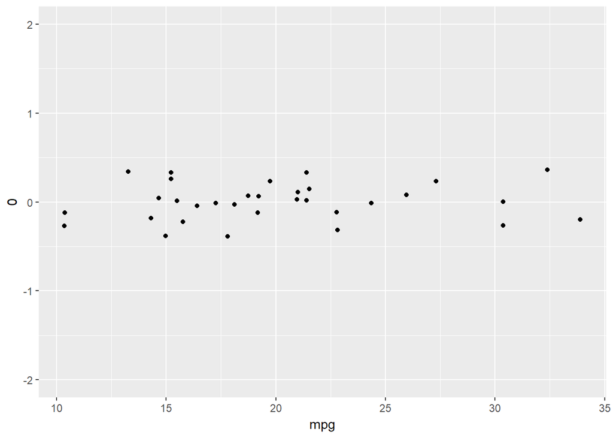

```r
ggplot(mtcars, aes(x=mpg, y=0)) + geom_jitter() + scale_y_continuous(limits = c(-2,2))
```

The above plot is known as `stripchart` which is a univariate plot

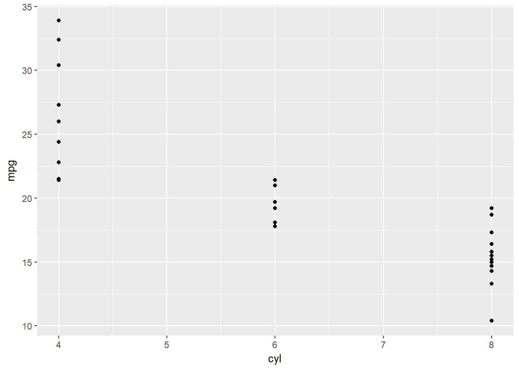

```r
ggplot(mtcars, aes(x = cyl, y = mpg)) + geom_point()
```

if we observe the dataset `mtcars` we will get to know that the variable `cyl` is categorical in nature but it is classified as numeric in the dataset. So we will need to tell `ggplot2` that `cyl` is a categorical variable.

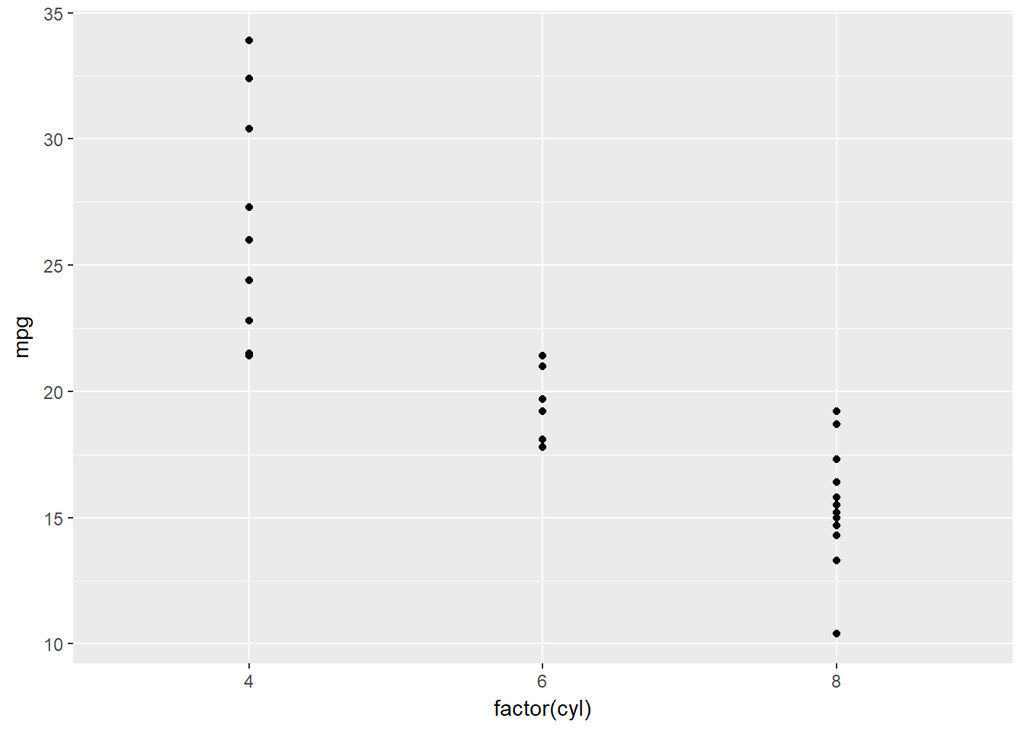

```r
ggplot(mtcars, aes(x = factor(cyl), y = mpg)) + geom_point()
```

Now we can see that `ggplot2` treats `cyl` as a factor. This time the x-axis does not contain the variables like 5 or 7, it contains only the values that are present in the dataset

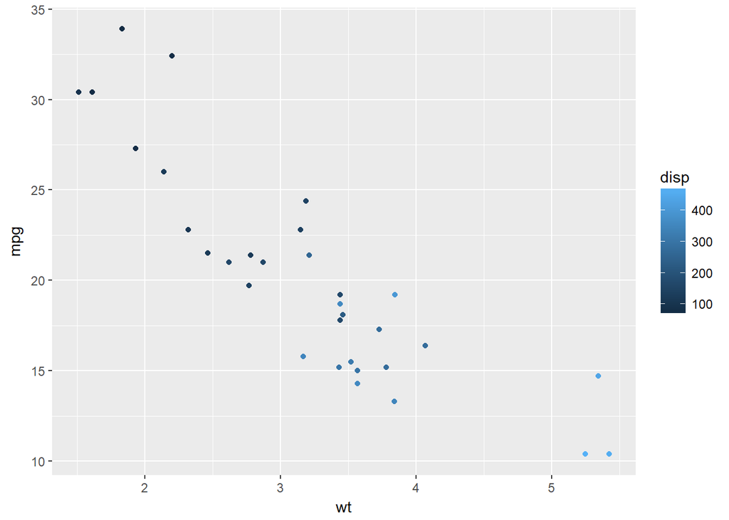

```r
ggplot(mtcars, aes(x = wt, y = mpg, color = disp)) + geom_point()
```

The above plot shows relationship between `mpg` and `wt` of the car with varying displacement `disp` of the car engine shown in different colors.

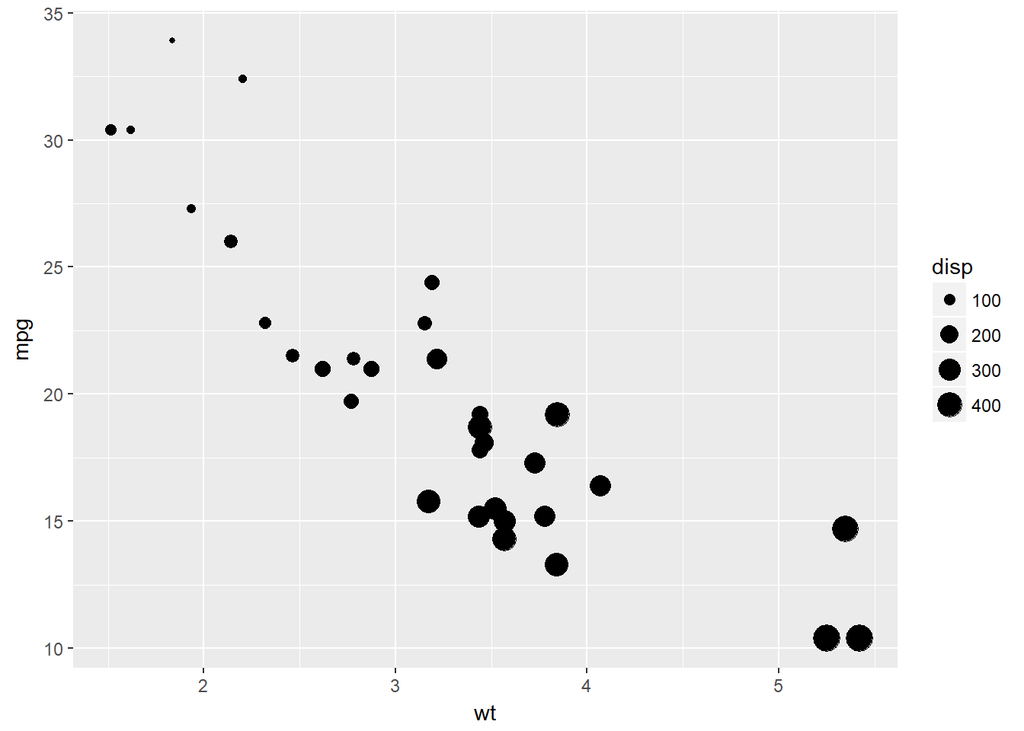

```r
ggplot(mtcars, aes(x = wt, y = mpg, size = disp)) + geom_point()
```

This plot also same as above, but this time dispalcement of the car engine is shown with varying sizes

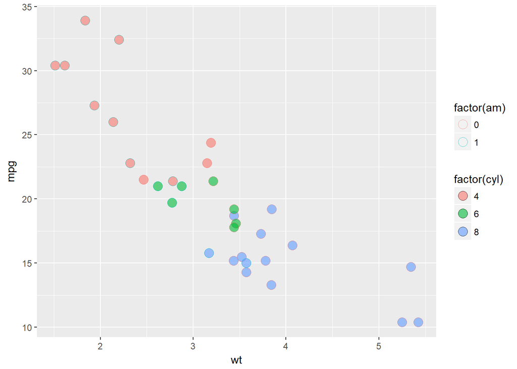

```r
ggplot(mtcars, aes(x = wt, y = mpg, col = factor(am), fill = factor(cyl))) +
  geom_point(shape = 21, size = 4, alpha = 0.6)
```

The above plot is used whenever we need to distinguish the data points based on two categorical variables

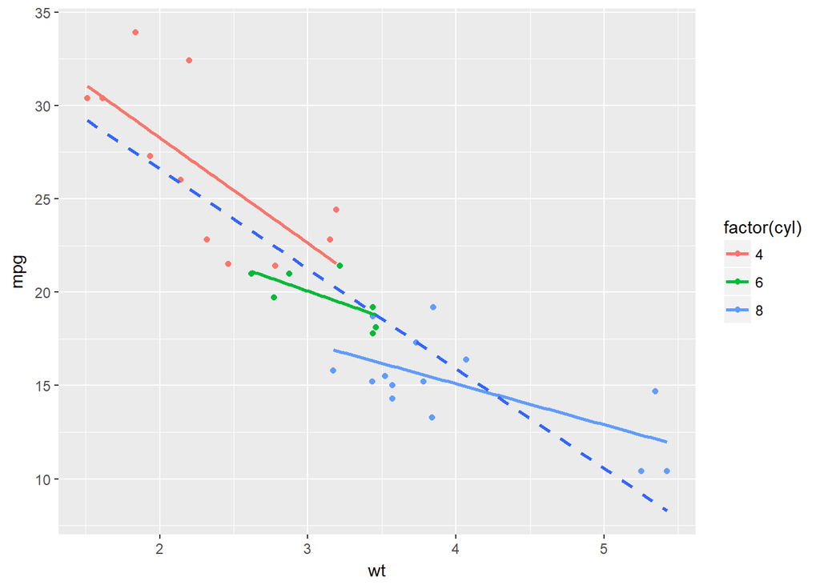

```r
ggplot(mtcars, aes(x = wt, y = mpg, col = factor(cyl))) +
  geom_point() +
  geom_smooth(method = "lm", se = FALSE) +
  geom_smooth(aes(group = 1), method = "lm", se = FALSE, linetype = 2)
```

The above plot shows linear models of different subgroups `cyl` variable

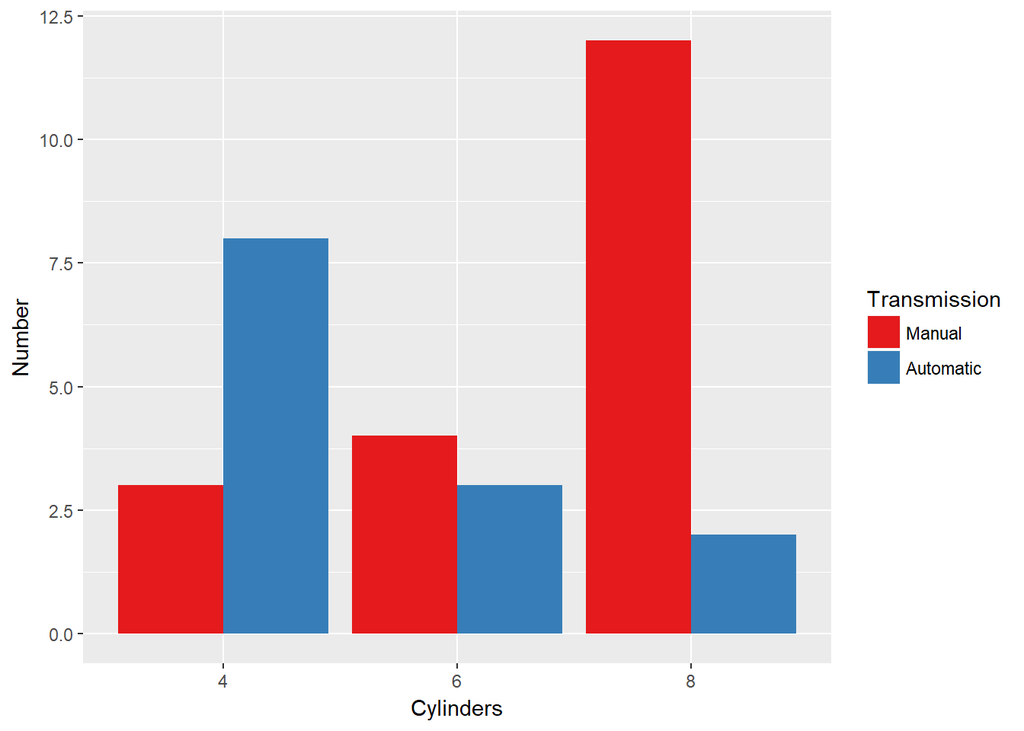

```r
val = c("#E41A1C", "#377EB8")
lab = c("Manual", "Automatic")
ggplot(mtcars, aes(x = factor(cyl), fill = factor(am))) +
  geom_bar(position = "dodge") +
  scale_x_discrete("Cylinders") +
  scale_y_continuous("Number") +
  scale_fill_manual("Transmission",
                    values = val,
                    labels = lab)
```

Plotting several distributions in the same panel

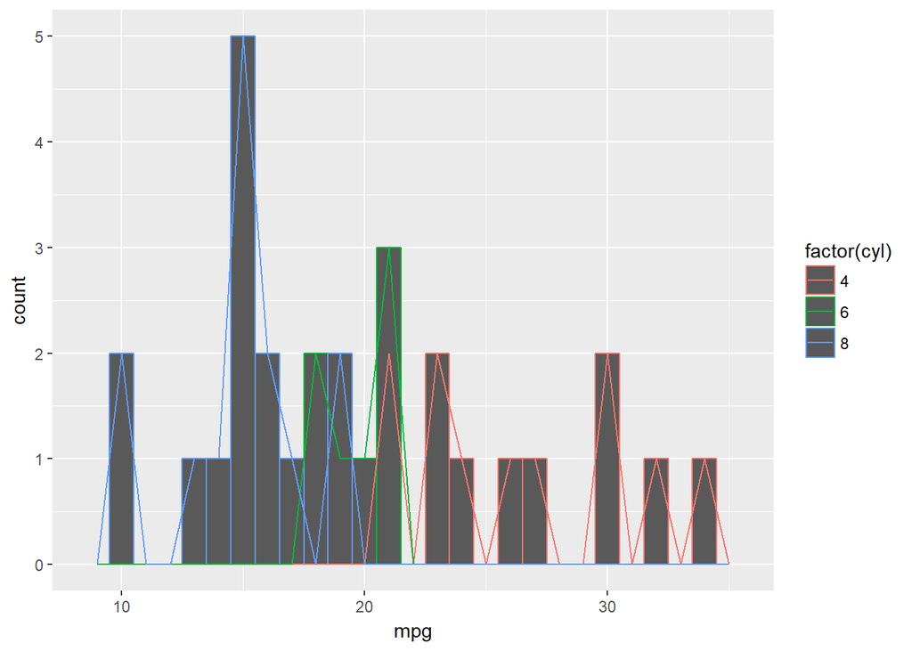

```r
ggplot(mtcars, aes(x=mpg, col=factor(cyl))) + geom_histogram(binwidth = 1, position = "identity") + geom_freqpoly(binwidth = 1)
```

In the above plot we can see the three different distributions of `cyl` variable displayed on the same panel. This plot is known as `Frequency Polygon` plot

## Daimond Dataset

Reducing the `overplotting` problem

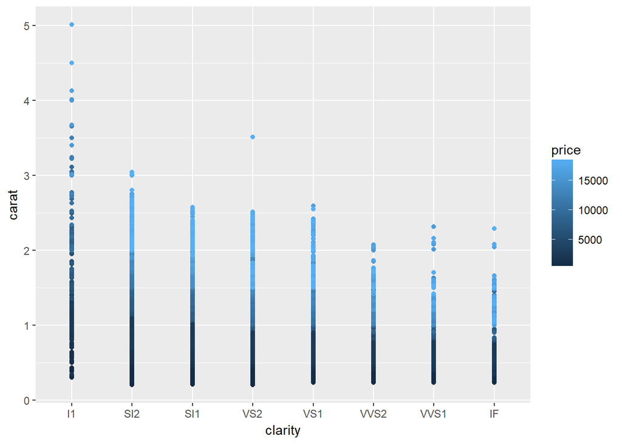

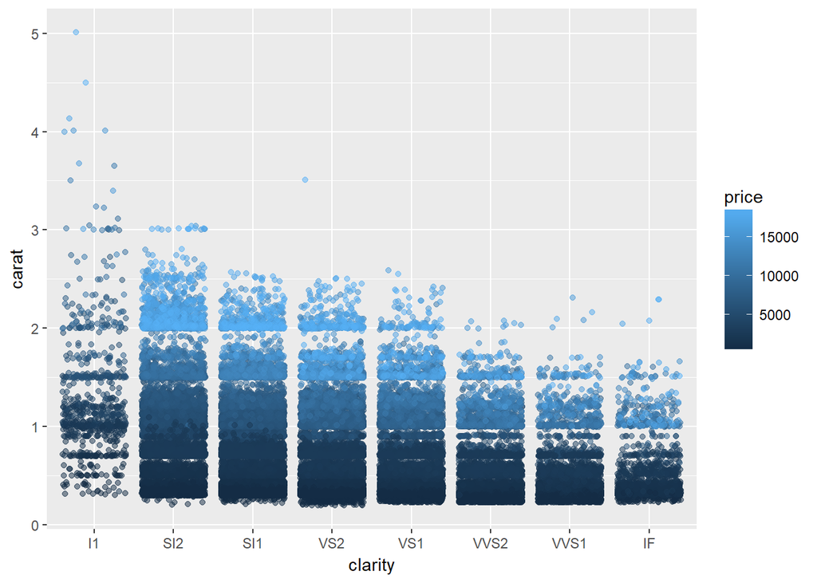

```r
ggplot(diamonds, aes(x=clarity, y=carat, color=price)) + geom_point()
ggplot(diamonds, aes(x=clarity, y=carat, color=price)) + geom_point(alpha=0.5, position = "jitter")
```

Adding a smoothing line

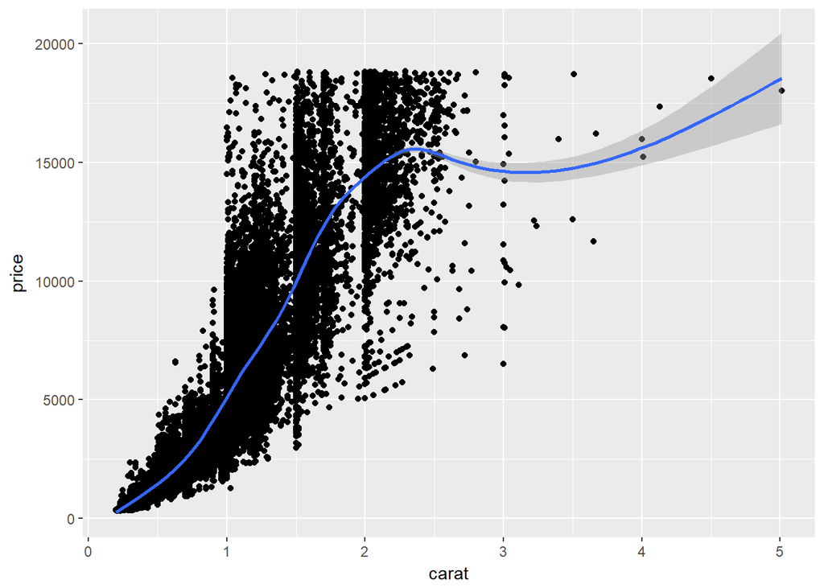

```r
ggplot(diamonds, aes(x = carat, y = price)) + geom_point() + geom_smooth()
```

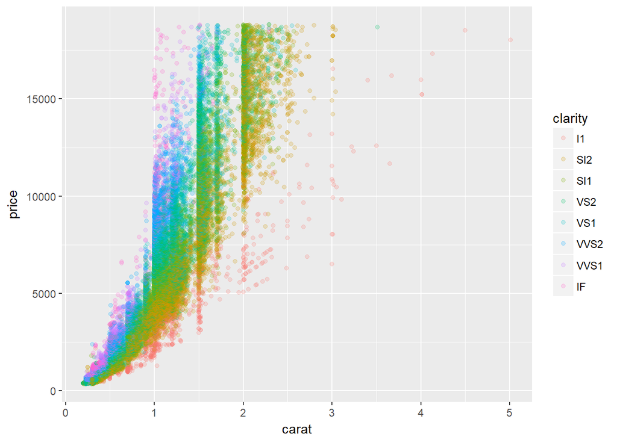

```r
ggplot(diamonds, aes(x = carat, y = price, color = clarity)) + geom_point(alpha = 0.2)
```

The `alpha` argument inside the geom_point() function makes the data points transparent

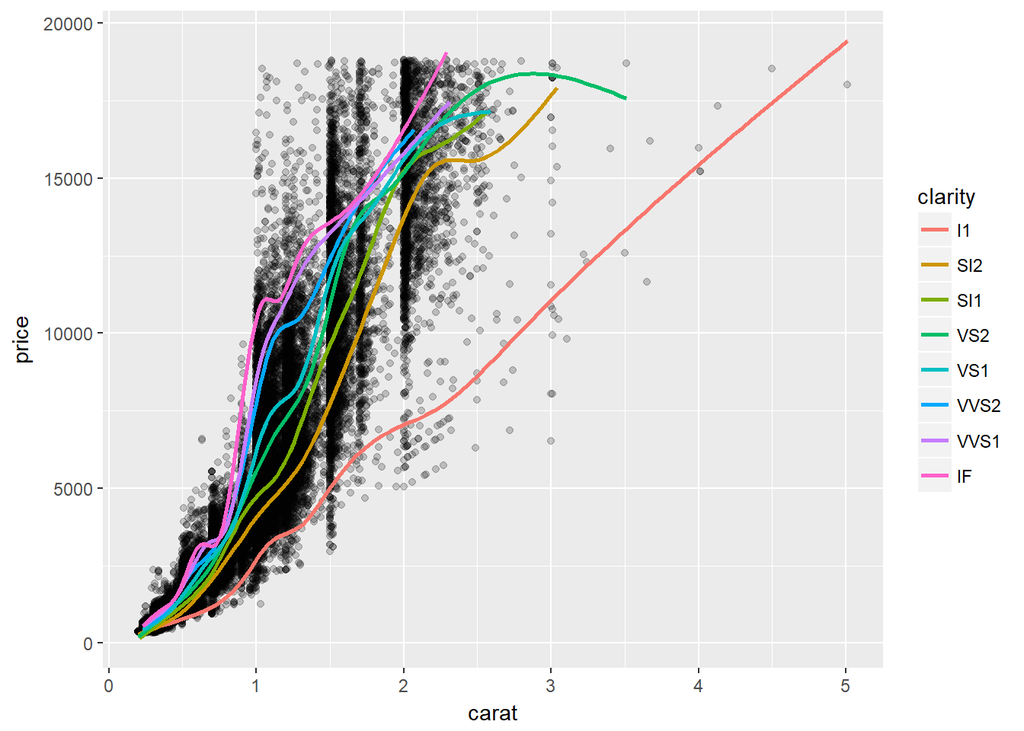

```r
ggplot(diamonds, aes(x = carat, y = price)) + geom_point(alpha = 0.2) + geom_smooth(aes(col = clarity), se = FALSE)
```

## Tidying the data to make a Plot

In this problem we will use the `iris` dataset and we will rearrange the dataset to make simple but meaningful plots

```r
library(tidyr)
data("iris")
```

Now we will tidy our `iris` dataset so that it is ready for plotting

```r
iris_tidy <- iris %>% gather(Key, Value, -Species) %>% separate(Key, c("Part", "Measure"), "\\.")
```

Now our dataset is ready for plotting

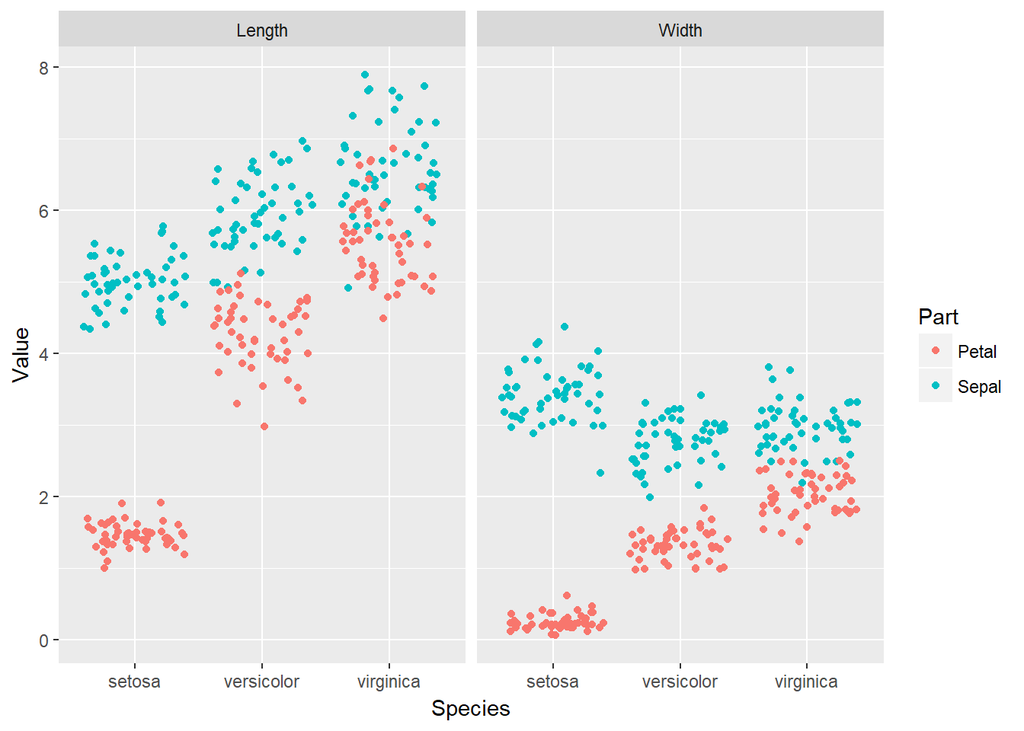

```r
ggplot(iris_tidy, aes(x = Species, y = Value, col = Part)) + geom_jitter() + facet_grid(. ~ Measure)
```

## Bar Plots with Color Ramp

we will use `Vocab` dataset from the `car` package

```r
library(car)
```

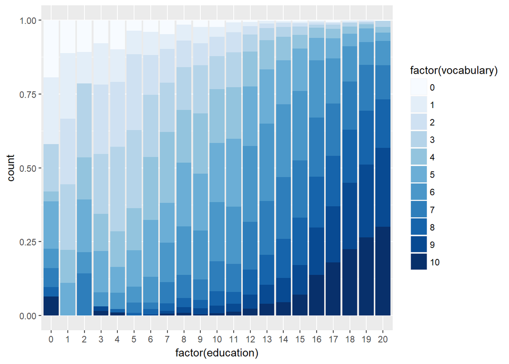

```r
library(RColorBrewer)
data("Vocab")
blues <- brewer.pal(9, "Blues") # from the RColorBrewer package
blue_range <- colorRampPalette(blues)
ggplot(Vocab, aes(x = factor(education), fill = factor(vocabulary))) +
  geom_bar(position = "fill") +
  scale_fill_manual(values = blue_range(11))
```